# Package ddpcr

Dean Attali

2026-01-14

# ddpcr: Analysis and visualization of Droplet Digital PCR data in R and on the web

[figure not shown]

> Created by [Dean Attali](https://deanattali.com)

This package provides an interface to explore, analyze, and visualize droplet digital PCR (ddPCR) data in R. It also includes an interactive web application with a visual user interface to facilitate analysis for anyone who is not comfortable with using R. The app is [available online](https://daattali.com/shiny/ddpcr/) or it can be run locally.

This document explains the purpose of this package and includes a tutorial on how to use it. It should take about 20 minutes to go through the entire document. A peer-reviewed publication describing this tool is available in [F1000Research](https://f1000research.com/articles/5-1411).

# Table of contents

- Background
- Overview
  - Main features
  - Supported experiment types
- Analysis using the interactive tool
- Analysis using R
  - Running the interactive tool locally through R
  - Quick start
  - Running a basic analysis - detailed walkthrough
    - Loading ddPCR data
    - Pre-analysis exploration of the data
    - Subset the plate
    - Run analysis
    - Post-analysis exploration of the data
    - Plot
    - Plot parameters
    - Save your data
  - Analysis of different plate types
    - Gating droplets in any ddPCR plate with custom thresholds
    - Gating droplets in PNPP experiments automatically
      - Clusters of a PNPP experiment
      - Analysis of a PNPP experiment
      - Results of a PNPP experiment
  - Advanced topic 1: Plate parameters
  - Advanced topic 2: Algorithms used in each step
  - Advanced topic 3: Creating new plate types
  - Advanced topic 4: Implementation technical details

# Background

Droplet Digital PCR (ddPCR) is a technology provided by Bio-Rad for performing digital PCR. The basic workflow of ddPCR involves three main steps: partitioning sample DNA into 20,000 droplets, PCR amplification of the nucleic acid in each droplet, and finally passing the droplets through a reader that detects fluorescence in two different wavelengths (generally set to detect FAM and HEX dyes). As a result, the data obtained from a ddPCR experiment can be visualized as a 2D scatterplot (one dimension is FAM intensity and the other dimension is HEX intensity) with 20,000 points (each droplet represents a point). The following figure is an example of a scatterplot from ddPCR data.

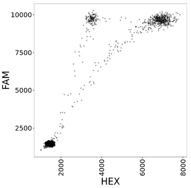

Sample ddPCR data

This package is designed to analyze two-channel ddPCR experiments (experiments utilizing both fluorescence channels). Single-channel experiments (where only one fluorescence channel is used) cannot use this tool.

A two-channel assay typically uses one FAM dye and one HEX dye, and consequently the droplets will be grouped into one of four clusters: double-positive (droplets that contain both target sequences and emit both HEX and FAM fluorescence), FAM-positive, HEX-positive, and double-negative (empty droplets without any amplifiable template that do not emit fluorescence in either channel). When plotting the droplets, each quadrant of the plot corresponds to a cluster; for example, the droplets in the lower-left quadrant are the double-negative droplets.

After running a ddPCR experiment, a key step in the analysis is gating the droplets to determine how many droplets belong to each cluster. Bio-Rad provides an analysis software called QuantaSoft which can be used to perform gating. QuantaSoft can either do the gating automatically or allow the user to set the gates manually. Most ddPCR users currently gate their data manually because QuantaSoft’s automatic gating often does a poor job and **there are no other tools available for gating ddPCR data**.

# Overview

The `ddpcr` package allows you to import your ddPCR data, perform some basic analysis, explore the data, and create customizable figures of the data.

## Main features

The main features include:

- **Identify failed wells** - identify wells with a failed ddPCR reaction. These wells will be excluded from all downstream analysis. No template control (NTC) wells will be deemed as failures by this tool.
- **Identify outlier droplets** - sometimes a few droplets can have an extremely high fluorescent intensity value that is probably erroneous, perhaps as a result of an error with the fluorescence reader. These droplets are identified and removed from the downstream analysis.
- **Identify empty droplets** - droplets with very low fluorescent amplitudes are considered empty and are removed from the downstream analysis. Removing these droplets is beneficial for two reasons: 1. the size of the data is greatly reduced, which means the computations will be faster on the remaining droplets, and 2. the real signal of interest is in the non-empty droplets, and empty droplets can be regarded as noise.
- **Calculating template concentration** - by knowing how many empty droplets are in each well, the starting concentration of the target DNA in the sample can be calculated (as number of copies of target template per microlitre of sample). Calculate the starting concentration of the target DNA molecule in the sample, defined as the number of copies per microlitre of input.
- **Gating droplets** - if your experiment matches some criteria (more on that soon), then automatic gating can take place; otherwise, you can gate the data with custom thresholds just like on QuantaSoft.
- **Explore results** - the results from each well (# of drops, # of outliers, # of empty drops, concentration, etc.) can be explored as a histogram or boxplot to see the distribution of all wells in the plate.
- **Plot** - you can plot the data in the plate with many customizable parameters

## Supported experiment types

While this tool was originally developed to automatically gate data for a particular ddPCR assay (*Quantitative Detection and Resolution of BRAF V600 Status in Colorectal Cancer Using Droplet Digital PCR and a Novel Wild-Type Negative Assay* by Roza Bidshahri, Dean Attali, et al.), any ddPCR experiment using an assay with similar characteristics can also use this tool to automatically gate the droplets. In order to benefit from the full automatic analysis, your ddPCR experiment needs to have these characteristics:

- The experiment uses a two-channel ddPCR assay with three expected droplet clusters: double-negative, double-positive, and single-positive.
- The majority of droplets are empty (double-negative).
- The majority of non-empty droplets are double-positive.
- There can be a third cluster of either FAM+ or HEX+ droplets, but not both.

In other words, the built-in automatic gating will work when there are three expected clusters of droplets: (1) double-negative, (2) double-positive, and (3) either FAM+ or HEX+. These types of experiments will be referred to as **(FAM+)/(FAM+HEX+)** or **(HEX+)/(FAM+HEX+)**. Both of these experiment types fall under the name of **PNPP experiments**; PNPP is short for PositiveNegative/PositivePositive, which is a reflection of the droplet clusters. Here is what a typical well from a PNPP experiment looks like:

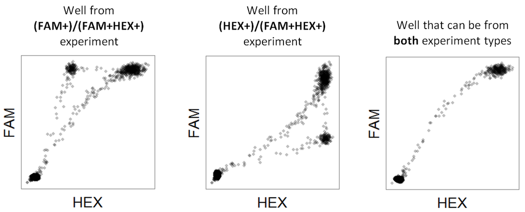

Supported experiment types

If your experiment matches the criteria for a **PNPP** experiment (either a **(FAM+)/(FAM+HEX+)** or a **(HEX+)/(FAM+HEX+)** experiment), then each droplet will be classified either as a rain droplet or as one of the three expected droplet clusters (FAM+, FAM+HEX+, or double-negative). Rain droplets are droplets that emit considerably more fluorescence than empty droplets, but do not emit enough fluorescence to be assigned into one of the main clusters. Here is the result of analyzing a single well from a **(FAM+)/(FAM+HEX+)** experiment:

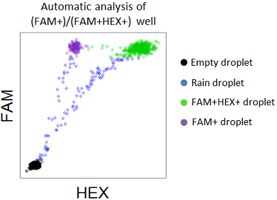

Analyze result

If your ddPCR experiment is not a **PNPP** type, you can still use this tool for the rest of the analysis, exploration, and plotting, but it will not benefit from the automatic gating. However, `ddpcr` is built to be easily extensible, which means that you can add your own experiment type. Custom experiment types need to define their own method for gating the droplets in a well, and then they can be used in the same way as the built-in experiment types.

> Note: throughout this document, *FAM* will be synonymous to *Y axis* and *HEX* will be synonymous to *X axis*, as a reflection of the fact that conventionally when visualizing the data the FAM intensity is plotted on the Y axis and the HEX intensity is on the X axis.

# Analysis using the interactive tool

If you’re not comfortable using R and would like to use a visual tool that requires no programming, you can [use the tool online](https://daattali.com/shiny/ddpcr/). You should still skim through the rest of this document (you can ignore the actual code/commands) as it will explain some important concepts.

# Analysis using R

Enough talking, let’s get our hands dirty.

First, install `ddpcr`

```r
install.packages("ddpcr")
```

## Running the interactive tool locally through R

Even if you do know R, using the interactive application can be easier and more convenient than running R commands. If you want to use the visual tool, simply run `ddpcr::launch()` and it will run the same application that’s hosted online on your own machine.

## Quick start

Here are two basic examples of how to use `ddpcr` to analyze and plot your ddPCR data. One example shows an analysis where the gating thresholds are manually set, and the other example uses the automated analysis. Explanation will follow, these are just here as a teaser.

> Note how `ddpcr` is designed to play nicely with the [magrittr pipe](https://github.com/tidyverse/magrittr) `%>%` for easier pipeline workflows.

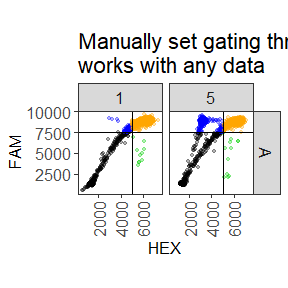

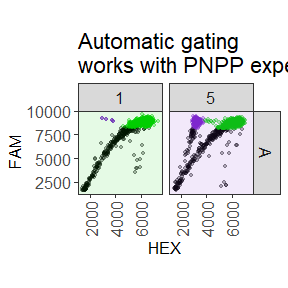

```r
library(ddpcr)
dir <- sample_data_dir()

# example 1: manually set thresholds
plate1 <-
  new_plate(dir, type = plate_types$custom_thresholds) %>%
  subset("A01,A05") %>%
  set_thresholds(c(5000, 7500)) %>%
  analyze()
plot(plate1, show_grid_labels = TRUE, alpha_drops = 0.3,
       title = "Manually set gating thresholds\nworks with any data")

# example 2: automatic gating
new_plate(dir, type = plate_types$fam_positive_pnpp) %>%
  subset("A01:A05") %>%
  analyze() %>%
  plot(show_mutant_freq = FALSE, show_grid_labels = TRUE, alpha_drops = 0.3,
       title = "Automatic gating\nworks with PNPP experiments")
```

## Running a basic analysis - detailed walkthrough

This section will go into details of how to use `ddpcr` to analyze ddPCR data.

### Loading ddPCR data

The first step is to get the ddPCR data into R. `ddpcr` uses the data files that are exported by QuantaSoft as its input. If you loaded an experiment named `2015-05-20_mouse` with 50 wells to QuantaSoft, then QuantaSoft can export the following files:

- 50 data files (well files): each well will have its own file with the name ending in `*_Amplitude.csv`. For example, the droplets in well A01 will be saved in `2015-05-20_mouse_A01_Amplitude.csv` (click on the **Export Amplitude and Cluster Data** button in the **Setup** tab).
- 1 results file: a small file named `2015-05-20_mouse.csv` will be generated with some information about the plate, including the name of the sample in each well (click on the **Export CSV** button in the **Analyze** tab).

The well files are the only required input to `ddpcr`, and since ddPCR plates contain 96 wells, you can upload anywhere from 1 to 96 well files. The results file is not mandatory, but if you don’t provide it then the wells will not have sample names attached to them.

`ddpcr` contains a sample dataset called `small` that has 5 wells. We use the `new_plate()` function to initialize a new ddPCR plate object. If given a directory, it will automatically find all the valid well files in the directory and attempt to find a matching results file.

```r
library(ddpcr)
dir <- sample_data_dir()
plate <- new_plate(dir)
```

```
#> Reading data files into plate... DONE (0 seconds)
#> Initializing plate of type `ddpcr_plate`... DONE (0 seconds)
```

You will see some messages appear - every time `ddpcr` runs an analysis step (initializing the plate is part of the analysis), it will output a message describing what it’s doing. You can turn off messages by disabling the verbose option with the command `options(ddpcr.verbose = FALSE)`.

### Pre-analysis exploration of the data

We can explore the data we loaded even before doing any analysis. The first and easiest thing to do is to plot the raw data.

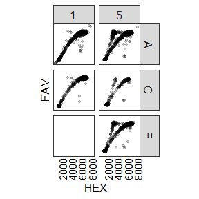

```r
plot(plate)
```

Another way to get a quick overview of the data is by simply printing the plate object.

```r
plate
```

```
#>                     ddpcr plate
#>                    -------------
#>             Dataset name : small
#>             Data summary : 5 wells; 72,727 drops
#>               Plate type : ddpcr_plate
#> Completed analysis steps : INITIALIZE
#> Remaining analysis steps : REMOVE_FAILURES, REMOVE_OUTLIERS, REMOVE_EMPTY
```

Among other things, this tells us how many wells and total droplets we have in the data, and what steps of the analysis are remaining. All the information that gets shown when you print a ddpcr plate object is also available through other functions that are dedicated to show one piece of information. For example

```r
plate %>% name()  # equivalent to `name(plate)`
```

```
#> [1] "small"
```

```r
plate %>% type()  # equivalent to `type(plate)`
```

```
#> [1] "ddpcr_plate"
```

Since we didn’t specify an experiment type, this plate object has the default type of `ddpcr_plate`.

We can see what wells are in our data with `wells_used()`

```r
plate %>% wells_used()
```

```
#> [1] "A01" "A05" "C01" "C05" "F05"
```

There are 5 wells because the sample data folder has 5 well files.

We can see all the droplets data with `plate_data()`

```r
plate %>% plate_data()
```

```
#> # A tibble: 72,727 × 4
#>    well    HEX   FAM cluster
#>    <chr> <int> <int>   <int>
#>  1 A01     577   494       1
#>  2 A01     515   495       1
#>  3 A01     690   645       1
#>  4 A01     929   860       1
#>  5 A01     844   868       1
#>  6 A01     942   907       1
#>  7 A01     985   923       1
#>  8 A01    1058   966       1
#>  9 A01    1058   979       1
#> 10 A01    1095  1002       1
#> # ℹ 72,717 more rows
```

> **Technical note**: This shows us the fluorescence amplitudes of each droplet, along with the current cluster assignment of each droplet. Right now all droplets are assigned to cluster 1 which corresponds to *undefined* since no analysis has taken place yet. You can see all the clusters that a droplet can belong to with the `clusters()` function

> ```
> plate %>% clusters()
> #> [1] "UNDEFINED" "FAILED"    "OUTLIER"   "EMPTY"
> ```

> This tells us that any droplet in a `ddpcr_plate`-type experiment can be classified into those clusters. Any droplet is initially *UNDEFINED*, droplets in failed wells are marked as *FAILED*, and the other two names are self-explanatory.

We can see the results of the plate so far with `plate_meta()`

```r
plate %>% plate_meta(only_used = TRUE)
```

```
#>   well sample row col used    target_ch1     target_ch2 drops
#> 1  A01   Dean   A   1 TRUE Consensus_FAM WTspecific_HEX 15820
#> 2  A05   Dave   A   5 TRUE Consensus_FAM WTspecific_HEX 13165
#> 3  C01   Mike   C   1 TRUE Consensus_FAM WTspecific_HEX 14256
#> 4  C05  Emily   C   5 TRUE Consensus_FAM WTspecific_HEX 14109
#> 5  F05   Mary   F   5 TRUE Consensus_FAM WTspecific_HEX 15377
```

The `only_used` parameter is used so that we’ll only get data about the 5 existing wells and ignore the other 91 unused wells on the plate. Notice that *meta* (short for *metadata*) is used instead of *results*. This is because the meta/results table contains information for each well such as its name, number of drops, number of empty drops, concentration, and many other calculated values.

### Subset the plate

If you aren’t interested in all the wells, you can use the `subset()` function to retain only certain wells. Alternatively, you can use the `data_files` argument of the `new_plate()` function to only load certain well files instead of a full directory.

The `subset()` function accepts either a list of sample names, a list of wells, or a special *range notation*. The range notation is a convenient way to select many wells: use a colon (`:`) to specify a range of wells and a comma (`,`) to add another well or range. A range of wells is defined as all wells in the rectangular area between the two endpoints. For example, `B05:C06` corresponds to the four wells `B05, B06, C05, C06`. The following diagram shows the result of subsetting with a range notation of `A01:H03, C05, E06, B07:C08` on a plate that initially contains all 96 wells.

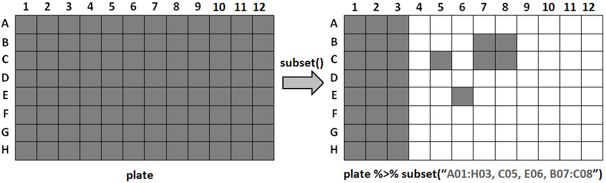

Subset example

Back to our data: we have 5 wells, let’s keep 4 of them

```r
plate <- plate %>% subset("A01:C05")
# could have also used subset("A01, A05, C01, C05")
plate %>% wells_used()
```

```
#> [1] "A01" "A05" "C01" "C05"
```

### Run analysis

An analysis of a ddPCR plate consists of running the plate through a sequence of steps. You can see the steps of an experiment by printing it.

```r
plate
```

```
#>                     ddpcr plate
#>                    -------------
#>             Dataset name : small
#>             Data summary : 4 wells; 57,350 drops
#>               Plate type : ddpcr_plate
#> Completed analysis steps : INITIALIZE
#> Remaining analysis steps : REMOVE_FAILURES, REMOVE_OUTLIERS, REMOVE_EMPTY
```

The last two lines show which steps have been completed and which steps remain. These steps are the default steps that any ddpcr plate will go through by default if no type is specified. At this point all we did was load the data, so the initialization step was done and there are 3 remaining steps. You can run all remaining steps with `analyze()`, or run through the steps one by one using `next_step()`.

```r
plate <- plate %>% analyze()
```

```
#> Identifying failed wells... DONE (0 seconds)
#> Identifying outlier droplets... DONE (0 seconds)
#> Identifying empty droplets... DONE (1 seconds)
#> Analysis complete
```

```r
# equivalent to `plate %>% next_step(3)`
# also equivalent to `plate %>% next_step() %>% next_step() %>% next_step()`
```

As each step of the analysis is performed, a message describing the current step is printed to the screen. Since we only have 4 wells, it should be very fast, but when you have a full 96-well plate, the analysis could take several minutes. Sometimes it can be useful to run each step individually rather than all of them together if you want to inspect the data after each step.

### Post-analysis exploration of the data

We can explore the plate again, now that it has been analyzed.

```r
plate
```

```
#>         ddpcr plate
#>        -------------
#> Dataset name : small
#> Data summary : 4 wells; 57,350 drops
#>   Plate type : ddpcr_plate
#>       Status : Analysis completed
```

We now get a message that says the analysis is complete (earlier it said which steps were remaining). We can also look at the droplets data

```r
plate %>% plate_data()
```

```
#> # A tibble: 57,350 × 4
#>    well    HEX   FAM cluster
#>    <chr> <int> <int>   <int>
#>  1 A01     577   494       4
#>  2 A01     515   495       4
#>  3 A01     690   645       4
#>  4 A01     929   860       4
#>  5 A01     844   868       4
#>  6 A01     942   907       4
#>  7 A01     985   923       4
#>  8 A01    1058   966       4
#>  9 A01    1058   979       4
#> 10 A01    1095  1002       4
#> # ℹ 57,340 more rows
```

This isn’t very informative since it shows the cluster assignment for each droplet, which is not easy for a human to digest. Instead, this information can be visualized by plotting the plate (coming up). We can also look at the plate results

```r
plate %>% plate_meta(only_used = TRUE)
```

```
#>   well sample row col used    target_ch1     target_ch2 drops success
#> 1  A01   Dean   A   1 TRUE Consensus_FAM WTspecific_HEX 15820    TRUE
#> 2  A05   Dave   A   5 TRUE Consensus_FAM WTspecific_HEX 13165    TRUE
#> 3  C01   Mike   C   1 TRUE Consensus_FAM WTspecific_HEX 14256    TRUE
#> 4  C05  Emily   C   5 TRUE Consensus_FAM WTspecific_HEX 14109   FALSE
#>   drops_outlier drops_empty drops_non_empty drops_empty_fraction concentration
#> 1             2       13690            2130                0.865           170
#> 2             1       11283            1882                0.857           181
#> 3             0       12879            1377                0.903           120
#> 4             0          NA              NA                   NA            NA
```

Now there’s a bit more information in the results table. The *success* column indicates whether or not the ddPCR run was successful in that particular well; notice how well `C05` was deemed a failure, and thus is not included the any subsequent analysis steps.

You can use the `well_info()` function to get the value of a specific variable of a specific well from the results. For example, we can query the plate object to see how many empty droplets are in well `A05`.

```r
well_info(plate, "A05", "drops_empty")
```

```
#> [1] 11283
```

### Plot

The easiest way to visualize a ddPCR plate is using the `plot()` function.

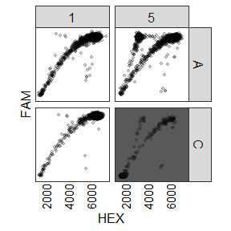

```r
plate %>% plot()
```

Notice well `C05` is grayed out, which means that it is a failed well. By default, failed wells have a grey background, and empty and outlier droplets are excluded from the plot.

You don’t have to analyze a plate object before you can plot it - a ddPCR plate can be plotted at any time to show the data in it. If you plot a plate before analyzing it, it’ll show the raw data.

### Plot parameters

There are many plot parameters to allow you to create extremely customizable plots. Among the many parameters, there are three special categories of parameters that affect the visibility of droplets: `show_drops_*` is used to show/hide certain droplets, `col_drops_*` is used to set the colour of droplets, and `alpha_drops_*` is used to set the transparency of droplets (0 = transparent, 1 = opaque). The `*` can be replaced by the name of any droplet cluster (the available clusters can be obtained with `clusters(plate)` as mentioned earlier). For example, to show the outlier droplets in blue, add the parameters `show_drops_outlier = TRUE, col_drops_outlier = "blue"`.

The following two plots show examples of how to use some plot parameters.

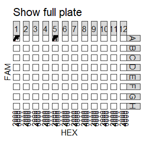

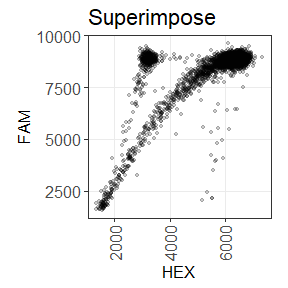

```r
plate %>% plot(wells = "A01,A05", show_full_plate = TRUE,
               show_drops_empty = TRUE, col_drops_empty = "red",
               title = "Show full plate")
plate %>% plot(wells = "A01,A05", superimpose = TRUE,
               show_grid = TRUE, show_grid_labels = TRUE, title = "Superimpose")
```

> To see all the available plot parameters, run `?plot.ddpcr_plate`.

### Save your data

As was shown previously, you can use the `plate_meta()` function to retrieve a table with the results. If you want to save that table, you can use R’s built-in `write.csv()` or `write.table()` functions.

```r
plate %>% save_plate("myplate")
from_file <- load_plate("myplate")
identical(plate, from_file)
```

```
#> [1] TRUE
```

```r
unlink("myplate.rds")
```

## Analysis of different plate types

So far we only used the default plate type in this analysis, but droplet gating does not take place with the default type. While you can define your own plate types (more on that later), there are three built-in plate types you can use:

1. **`plate_types$custom_thresholds`** - when you want to gate your droplets into four quadrants according to HEX and FAM values that you set
2. **`plate_types$fam_positive_pnpp`** - when you have a FAM-positive PNPP plate (FAM+)/(FAM+HEX+)
3. **`plate_types$hex_positive_pnpp`** - when you have a HEX-positive PNPP plate (HEX+)/(FAM+HEX+)

The next two sections explain how to use these experiment types.

### Gating droplets in any ddPCR plate with custom thresholds

If you want to perform a simple 4-quadrant gating like the one available in QuantaSoft, you need to set the type of the plate object to `plate_types$custom_thresholds`. This can either be done when initializing a new plate or by resetting an existing plate object.

```r
# two ways to create the desired plate
plate_manual <- reset(plate, type = plate_types$custom_thresholds)
plate_manual2 <- new_plate(dir, type = plate_types$custom_thresholds) %>%
  subset("A01:C05")

# make sure the two methods above are identical
identical(plate_manual, plate_manual2)
```

```
#> [1] TRUE
```

```r
plate_manual
```

```
#>                     ddpcr plate
#>                    -------------
#>             Dataset name : small
#>             Data summary : 4 wells; 57,350 drops
#>               Plate type : custom_thresholds, ddpcr_plate
#> Completed analysis steps : INITIALIZE
#> Remaining analysis steps : REMOVE_OUTLIERS, CLASSIFY
```

It’s usually a good idea to take a look at the raw data to decide where the draw the thresholds

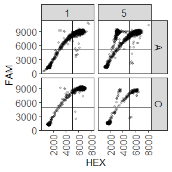

```r
plot(plate_manual, show_grid_labels = TRUE)
```

If you noticed, there’s a droplet in well *A05* that has a much larger fluorescence value and is probably an outlier, which is the reason the scale is a bit too large. After analyzing the plate, it will be identified as an outlier and hidden automatically. Before running the analysis, we should set where the thresholds will be. By default, the thresholds are at (5000, 5000), which is very arbitrary. It looks like the x coordinate is fine, but the y border should move up to approximately 8000. Then run the analysis.

```r
# what are the current thresholds?
thresholds(plate_manual)
```

```
#> [1] "(5000, 5000)"
```

```r
# set the thresholds to (5000,8000)
thresholds(plate_manual) <- c(5000, 8000)
plate_manual <- analyze(plate_manual)
```

```
#> Identifying outlier droplets... DONE (0 seconds)
#> Classifying droplets... DONE (0 seconds)
#> Analysis complete
```

Now the plate is ready and we can plot it or look at its results

```r
plate_meta(plate_manual, only_used = TRUE)
```

```
#>   well sample row col used    target_ch1     target_ch2 drops drops_outlier
#> 1  A01   Dean   A   1 TRUE Consensus_FAM WTspecific_HEX 15820             2
#> 2  A05   Dave   A   5 TRUE Consensus_FAM WTspecific_HEX 13165             1
#> 3  C01   Mike   C   1 TRUE Consensus_FAM WTspecific_HEX 14256             0
#> 4  C05  Emily   C   5 TRUE Consensus_FAM WTspecific_HEX 14109             0
#>   drops_empty drops_x_positive drops_y_positive drops_both_positive
#> 1       13909               20               20                1869
#> 2       11512               34              390                1228
#> 3       12967                8                7                1274
#> 4       14011               15               11                  72
```

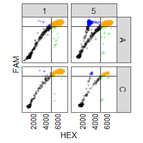

```r
plot(plate_manual)
```

By default, the droplets in each quadrant are a different colour. If you want to change the colour of some droplets, we can use the `col_drops_*` parameter as before. Since now we’re working with a different plate type, the names of the droplet clusters can be different, so we need to first know what they are

```r
clusters(plate_manual)
```

```
#> [1] "UNDEFINED"     "OUTLIER"       "EMPTY"         "X_POSITIVE"
#> [5] "Y_POSITIVE"    "BOTH_POSITIVE"
```

Now if we want to change the colour of the double-positive droplets to red, we just add a parameter `col_drops_both_positive = "red"`.

> To see all the available plot parameters for this plate type, run `?plot.custom_thresholds`. In addition, any plot parameter that is available for default plates can also be used here (all parameters listed under `?plot.ddpcr_plate`).

### Gating droplets in PNPP experiments automatically

If you have a *PNPP* experiment (*(FAM+)/(FAM+HEX+)* or *(HEX+)/(FAM+HEX+)*), then `ddpcr` can perform a fully automatic analysis on the plate. The sample dataset used in this running example is from a *(FAM+)/(FAM+HEX+)* experiment, so we can take advantage of the automatic gating if we set the type to `plate_types$fam_positive_pnpp`.

Let’s create a new plate object of the desired type.

```r
plate_pnpp <- new_plate(dir, type = plate_types$fam_positive_pnpp)
```

```
#> Reading data files into plate... DONE (0 seconds)
#> Initializing plate of type `fam_positive_pnpp`... DONE (0 seconds)
```

If the data were *(HEX+)/(FAM+HEX+)*, we would have used `type = plate_types$hex_positive_pnpp` instead.

#### Clusters of a PNPP experiment

Before running the analysis, it’s a good idea to know what are the possible cluster groupings that a droplet can belong to

```r
clusters(plate_pnpp)
```

```
#> [1] "UNDEFINED" "FAILED"    "OUTLIER"   "EMPTY"     "RAIN"      "POSITIVE"
#> [7] "NEGATIVE"
```

The first 4 clusters we’ve seen before, as they are common to all plate types. Droplets in the *HEX+FAM+* cluster are considered *POSITIVE*, while droplets in the *FAM+* cluster are considered *NEGATIVE* since they are *HEX-*. Any droplets that are not empty but don’t emit enough fluorescent intensity to be in the *POSITIVE* or *NEGATIVE* clusters are considered *RAIN*.

> When using the `plate_types$fam_positive_pnpp` type, the positive droplets (FAM+HEX+) are called wildtype, and the negative droplets (FAM+HEX-) are called mutant. Why? This package was originally designed to analyze a specific assay where the FAM+HEX+ cluster represented droplets with a wildtype gene inside, while the FAM+HEX- cluster corresponded to droplets with a mutant gene. Talking about positive vs negative drops or positive vs negative wells sounds a bit weird, so it was decided to stick with mutant vs wildtype. Just remember: wildtype = double-positive droplets, mutant = singly-positive droplets.

#### Analysis of a PNPP experiment

Now we can analyze the plate

```r
plate_pnpp <- analyze(plate_pnpp)
```

```
#> Identifying failed wells... DONE (0 seconds)
#> Identifying outlier droplets... DONE (0 seconds)
#> Identifying empty droplets... DONE (1 seconds)
#> Classifying droplets... DONE (1 seconds)
#> Reclassifying droplets... skipped (not enough wells with significant mutant clusters)
#> Analysis complete
```

One of the key goals in running the analysis is to determine the number of *POSITIVE* (wildtype) and *NEGATIVE* (mutant) droplets in each well, and similarly the *mutant frequency* (if a well has 95 wildtype droplets and 5 mutant droplets, then the *mutant frequency* in the well is 5%).

You can see from the output that the two last steps are **classifying** and **reclassifying** the droplets, and that the reclassification didn’t take place. The classification step identifies all the non-empty droplets as either rain, mutant, or wildtype by analyzing each well individually. Wells with a very low *mutant frequency* (i.e. there are very few mutant droplets) are much harder to gate accurately, which is the reason for the reclassification step. The reclassification step uses information from wells with high a *mutant frequency*, where the gates are more clearly defined, to adjust the gates in wells with a low *mutant frequency*. The reclassification step only takes place if there are enough wells with a high mutant frequency.

#### Results of a PNPP experiment

Take a look at the results

```r
plate_pnpp %>% plate_meta(only_used = TRUE)
```

```
#>   well sample row col used    target_ch1     target_ch2 drops success
#> 1  A01   Dean   A   1 TRUE Consensus_FAM WTspecific_HEX 15820    TRUE
#> 2  A05   Dave   A   5 TRUE Consensus_FAM WTspecific_HEX 13165    TRUE
#> 3  C01   Mike   C   1 TRUE Consensus_FAM WTspecific_HEX 14256    TRUE
#> 4  F05   Mary   F   5 TRUE Consensus_FAM WTspecific_HEX 15377    TRUE
#> 5  C05  Emily   C   5 TRUE Consensus_FAM WTspecific_HEX 14109   FALSE
#>   drops_outlier drops_empty drops_non_empty drops_empty_fraction concentration
#> 1             2       13690            2130                0.865           170
#> 2             1       11283            1882                0.857           181
#> 3             0       12879            1377                0.903           120
#> 4             0       14126            1251                0.919            99
#> 5             0          NA              NA                   NA            NA
#>   mutant_border filled_border significant_mutant_cluster mutant_num
#> 1          4194          8286                      FALSE          4
#> 2          3789          8136                       TRUE        368
#> 3          4356          8445                      FALSE          3
#> 4          3926          8294                       TRUE        211
#> 5            NA            NA                         NA         NA
#>   wildtype_num mutant_freq
#> 1         1827       0.218
#> 2         1224      23.100
#> 3         1248       0.240
#> 4          855      19.800
#> 5           NA          NA
```

Plotting the data is usually the best way to see the results

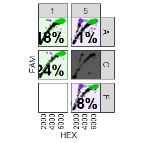

```r
plate_pnpp %>% plot(text_size_mutant_freq = 8)
```

> To see all the available plot parameters for this plate type, run `?plot.pnpp_experiment`. In addition, any plot parameter that is available for default plates can also be used here (all parameters listed under `?plot.ddpcr_plate`).

The wildtype droplets are green and the mutant droplets are purple. The well colours themselves reflect the **significant_mutant_cluster** variable: wells that are mostly wildtype droplets are green, and wells with significant mutant clusters are purple. There are parameters to set all these colours, the transparency levels, and many more options.

Similar to how `wells_failed()` returns the failed wells, you can use the `wells_mutant()` and `wells_wildtype()` functions to extract the wells with a significant mutant cluster and those without.

```r
plate_pnpp %>% wells_mutant()
```

```
#> [1] "A05" "F05"
```

```r
plate_pnpp %>% wells_wildtype()
```

```
#> [1] "A01" "C01"
```

## Advanced topic 1: Plate parameters

Every ddPCR plate object has adjustable parameters associated with it. There are general parameters that apply to the plate as a whole, and each analysis step has its own set of parameters that are used for the algorithm in that step. You can see all the parameters of a plate using the `params()` function

```r
plate %>% params() %>% str()
```

```
#> List of 4
#>  $ GENERAL        :List of 4
#>   ..$ X_VAR         : chr "HEX"
#>   ..$ Y_VAR         : chr "FAM"
#>   ..$ DROPLET_VOLUME: num 0.00085
#>   ..$ RANDOM_SEED   : num 8
#>  $ REMOVE_FAILURES:List of 3
#>   ..$ TOTAL_DROPS_T      : num 5000
#>   ..$ EMPTY_LAMBDA_LOW_T : num 0.3
#>   ..$ EMPTY_LAMBDA_HIGH_T: num 0.99
#>  $ REMOVE_OUTLIERS:List of 2
#>   ..$ TOP_PERCENT: num 1
#>   ..$ CUTOFF_IQR : num 5
#>  $ REMOVE_EMPTY   :List of 1
#>   ..$ CUTOFF_SD: num 7
```

You can also view the parameters for a specific step or the value of a parameter. For example, to see the parameters used in the step that identifies failed wells, use

```r
plate %>% params("REMOVE_FAILURES")
```

```
#> $TOTAL_DROPS_T
#> [1] 5000
#>
#> $EMPTY_LAMBDA_LOW_T
#> [1] 0.3
#>
#> $EMPTY_LAMBDA_HIGH_T
#> [1] 0.99
```

You can also view or edit specific parameters. When identifying failed wells, one of the conditions for a successful run is to have at least 5,000 droplets in the well (Bio-Rad claims that every well has 20,000 droplets). If you know that your particular experiment had much fewer droplets than usual and as a result `ddpcr` thinks that all the wells are failures, you can change the setting

```r
params(plate, "REMOVE_FAILURES", "TOTAL_DROPS_T")
```

```
#> [1] 5000
```

```r
params(plate, "REMOVE_FAILURES", "TOTAL_DROPS_T") <- 1000
params(plate, "REMOVE_FAILURES", "TOTAL_DROPS_T")
```

```
#> [1] 1000
```

If you look at the full parameters of the plate, you’ll notice that by default `ddpcr` assumes that the dyes used are *FAM* and *HEX*. If you are using a different dye and want the name of that dye appear in the results instead, you can use the `x_var()` or `y_var()` functions.

```r
orig_x <- x_var(plate)
orig_x
```

```
#> [1] "HEX"
```

```r
x_var(plate) <- "VIC"
plate %>% plate_data() %>% names()
```

```
#> [1] "well"    "VIC"     "FAM"     "cluster"
```

```r
x_var(plate) <- orig_x
```

Note that if you change any parameters, you need to re-run the analysis. If you try running `analyze()` after a plate has already been analyzed, you will simply get a message saying the plate is already analyzed. To force an already-analyzed plate to re-run the analysis, you need to use the `restart = TRUE` parameter.

```r
plate <- analyze(plate)
```

```
#> Analysis complete
```

```r
plate <- analyze(plate, restart = TRUE)
```

```
#> Restarting analysis
```

```
#> Initializing plate of type `ddpcr_plate`... DONE (0 seconds)
#> Identifying failed wells... DONE (0 seconds)
#> Identifying outlier droplets... DONE (0 seconds)
#> Identifying empty droplets... DONE (1 seconds)
#> Analysis complete
```

## Advanced topic 2: Algorithms used in each step

If you want to know how a step is performed, you can see the exact algorithm (code) used in each step by consulting the `steps()` function.

```r
plate_pnpp %>% steps
```

```
#> $INITIALIZE
#> [1] "init_plate"
#>
#> $REMOVE_FAILURES
#> [1] "remove_failures"
#>
#> $REMOVE_OUTLIERS
#> [1] "remove_outliers"
#>
#> $REMOVE_EMPTY
#> [1] "remove_empty"
#>
#> $CLASSIFY
#> [1] "classify_droplets"
#>
#> $RECLASSIFY
#> [1] "reclassify_droplets"
```

This list contains all the steps of analyzing the given plate, with each item in the list containing both the name of the step and the R function that performs it. For example, the first step is *INITIALIZE* and it uses the function `init_plate()`. You can see the code for that function by running `ddpcr:::init_plate`.

```r
ddpcr:::init_plate
```

```
#> function (plate)
#> {
#>     stopifnot(plate %>% inherits("ddpcr_plate"))
#>     step_begin(sprintf("Initializing plate of type `%s`", type(plate)))
#>     plate %<>% set_default_clusters %>% set_default_steps %>%
#>         init_data %>% init_meta
#>     status(plate) <- step(plate, "INITIALIZE")
#>     plate[["version"]] <- as.character(utils::packageVersion("ddpcr"))
#>     plate[["dirty"]] <- FALSE
#>     step_end()
#>     plate
#> }
#> <bytecode: 0x000002b11bd07e38>
#> <environment: namespace:ddpcr>
```

**For more details about the algorithm, see the *Algorithms* vignette.**

## Advanced topic 3: Creating new plate types

Each ddPCR plate has a plate type which determines what type of analysis to run on the data. `plate_types` contains a list of the built-in plate types that are supported, but you can also create your own plate type. Create a new plate type if you want to supply your own logic for any analysis step, or even if you simply want to have a type that sets different default parameters than the built-in ones.

**For more details about how to create new plate types, see the *Extending ddpcr by adding new plate types* vignette.**

## Advanced topic 4: Implementation technical details

The `ddpcr` package uses some advanced R programming techniques.

**For details on the technical details regarding the code implementation, see the *Technical details* vignette.**